# Exploratory data analysis with R

Dr. Wasilios Hariskos

23. Oktober 2020

# Load packages and data

```r
# install.packages("gridExtra")
library(gridExtra) # for data visualization
library(ggplot2) # for data visualization
library(dplyr) # for data tranformation
library(gapminder) # excerpt of the Gapminder data
```

# Dataset

We focus on a subset of the gapminder dataset that contains only observations from the year 1997.

```r
gapminder_1997 <- gapminder %>%
  filter(year == "1997")

glimpse(gapminder_1997)
```

```
## Observations: 142
## Variables: 6
## $ country   <fct> Afghanistan, Albania, Algeria, Angola, Argentina, Au...
## $ continent <fct> Asia, Europe, Africa, Africa, Americas, Oceania, Eur...
## $ year      <int> 1997, 1997, 1997, 1997, 1997, 1997, 1997, 1997, 1997...
## $ lifeExp   <dbl> 41.763, 72.950, 69.152, 40.963, 73.275, 78.830, 77.5...
## $ pop       <int> 22227415, 3428038, 29072015, 9875024, 36203463, 1856...
## $ gdpPercap <dbl> 635.3414, 3193.0546, 4797.2951, 2277.1409, 10967.282...
```

We tranform the numerical variables `lifeExp` and `gdpPercap` to categorical variables using the functions `quantiles` and `cut`.

```r
breaks_lifeExp <- quantile(x = gapminder_1997$lifeExp,
                           probs = c(0, 1/3, 2/3, 1))
breaks_lifeExp
```

```
##        0% 33.33333% 66.66667%      100%
##    36.087    60.236    72.312    80.690
```

```r
breaks_gdpPercap <- quantile(x = gapminder_1997$gdpPercap,
                             probs = c(0, 1/3, 2/3, 1))
breaks_gdpPercap
```

```
##         0%  33.33333%  66.66667%       100%
##   312.1884  2049.3505  8754.9639 41283.1643
```

```r
categorical_1997 <- gapminder_1997 %>%
  mutate(lifeExpCat = cut(x = lifeExp,
                          breaks = breaks_lifeExp,
                          labels = c("low", "middle", "high")),
         gdpPercapCat = cut(x = gdpPercap,
                          breaks = breaks_gdpPercap,
                          labels = c("low", "middle", "high")))

glimpse(categorical_1997)
```

```
## Observations: 142
## Variables: 8
## $ country      <fct> Afghanistan, Albania, Algeria, Angola, Argentina,...
## $ continent    <fct> Asia, Europe, Africa, Africa, Americas, Oceania, ...
## $ year         <int> 1997, 1997, 1997, 1997, 1997, 1997, 1997, 1997, 1...
## $ lifeExp      <dbl> 41.763, 72.950, 69.152, 40.963, 73.275, 78.830, 7...
## $ pop          <int> 22227415, 3428038, 29072015, 9875024, 36203463, 1...
## $ gdpPercap    <dbl> 635.3414, 3193.0546, 4797.2951, 2277.1409, 10967....
## $ lifeExpCat   <fct> low, high, middle, low, high, high, high, high, l...
## $ gdpPercapCat <fct> low, middle, middle, middle, high, high, high, hi...
```

We check the levels of the new categorical variables

```r
levels(categorical_1997$lifeExpCat)
```

```
## [1] "low"    "middle" "high"
```

```r
levels(categorical_1997$gdpPercapCat)
```

```
## [1] "low"    "middle" "high"
```

We check with `table` if the data categorization was correct:

```r
table(categorical_1997$lifeExpCat)
```

```
##
##    low middle   high
##     47     47     47
```

```r
table(categorical_1997$gdpPercapCat)
```

```
##
##    low middle   high
##     47     47     47
```

# Explore categorical data

## Marginal barchart

We use `table()` to display the number of countries of by continent.

```r
table(categorical_1997$continent)
```

```
##
##   Africa Americas     Asia   Europe  Oceania
##       52       25       33       30        2
```

We visualize this information with a simple marginal barchart.

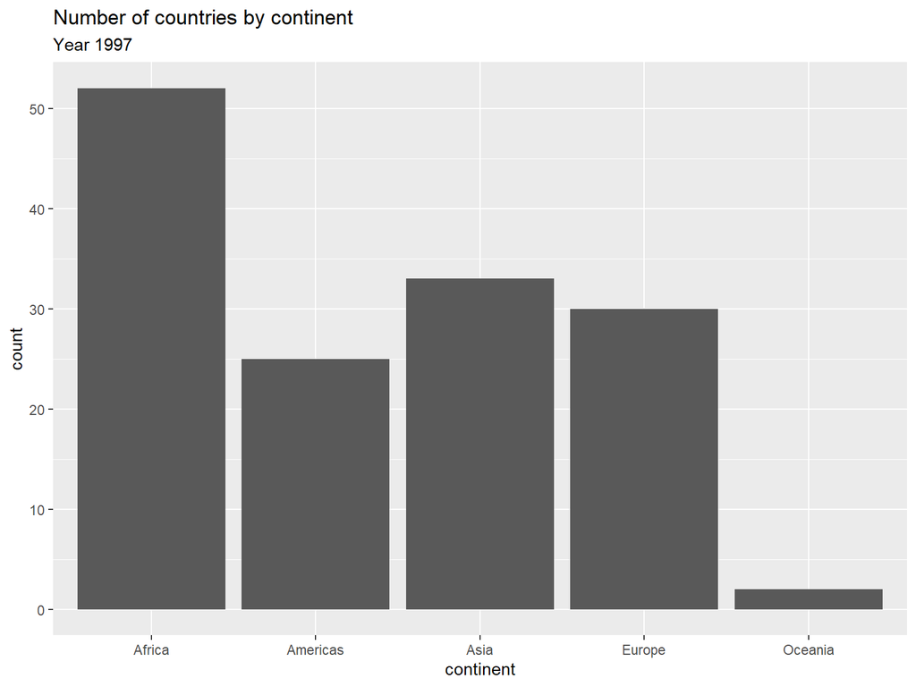

```r
ggplot(data = categorical_1997) +
  geom_bar(mapping = aes(x = continent)) +
  ggtitle(label = "Number of countries by continent",
          subtitle = "Year 1997")
```

## Contingency table

We use `table()` to create a contingency table of the counts of countries at each combination of factor levels of `continent` and `lifeExpCat`:

```r
table(categorical_1997$continent,
      categorical_1997$lifeExpCat)
```

```
##
##            low middle high
##   Africa    40     10    1
##   Americas   1     14   10
##   Asia       6     18    9
##   Europe     0      5   25
##   Oceania    0      0    2
```

## Conditional barchart

We visualize the contingency table with a conditional barchart by faceting `lifeExp` based on `continent`.

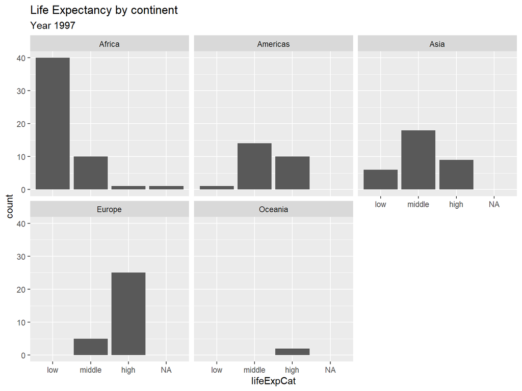

```r
ggplot(data = categorical_1997) +
  geom_bar(mapping = aes(x = lifeExpCat)) +
  facet_wrap(facets = ~ continent) +
  ggtitle(label = "Life Expectancy by continent",
          subtitle = "Year 1997")
```

## Contingency table and stacked barchart

We can also visualize the contingency table with a stacked barchart by mapping `lifeExpCat` to the `fill` aesthetic.

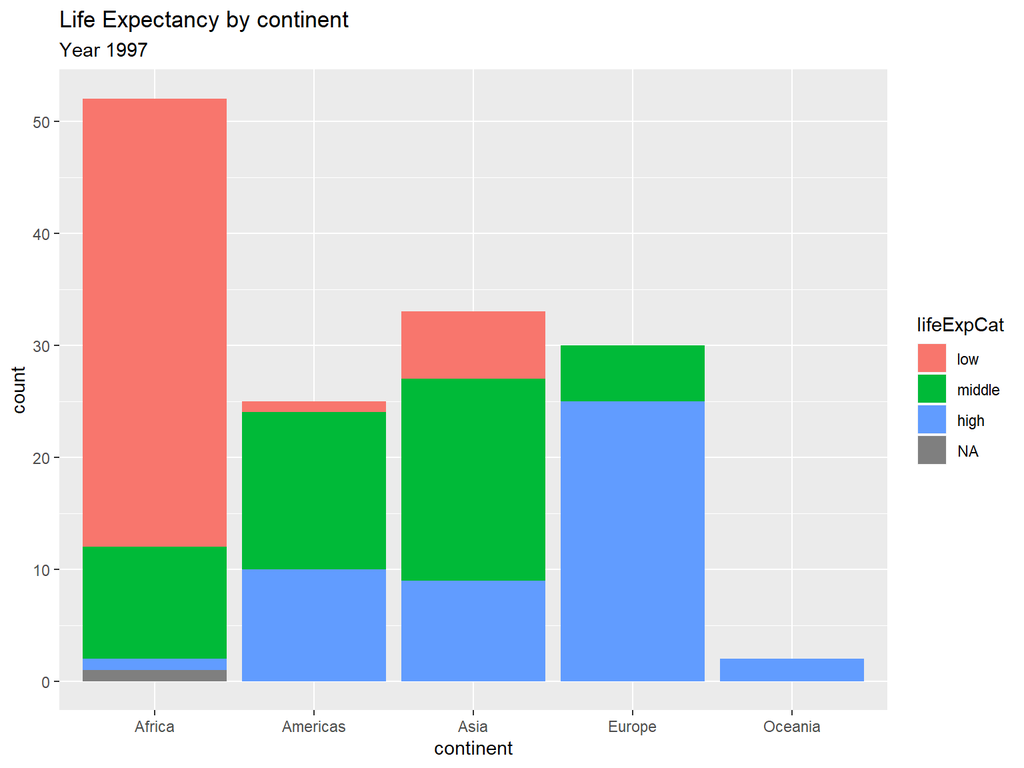

```r
ggplot(data = categorical_1997) +
  geom_bar(mapping = aes(x = continent,
                         fill = lifeExpCat)) +
  ggtitle(label = "Life Expectancy by continent",
          subtitle = "Year 1997")
```

## Side-by-side barcharts

The same information depicted in the stacked bar chart can be displayed by a side-by-side barchart. To do so, we set `position = "dodge"`.

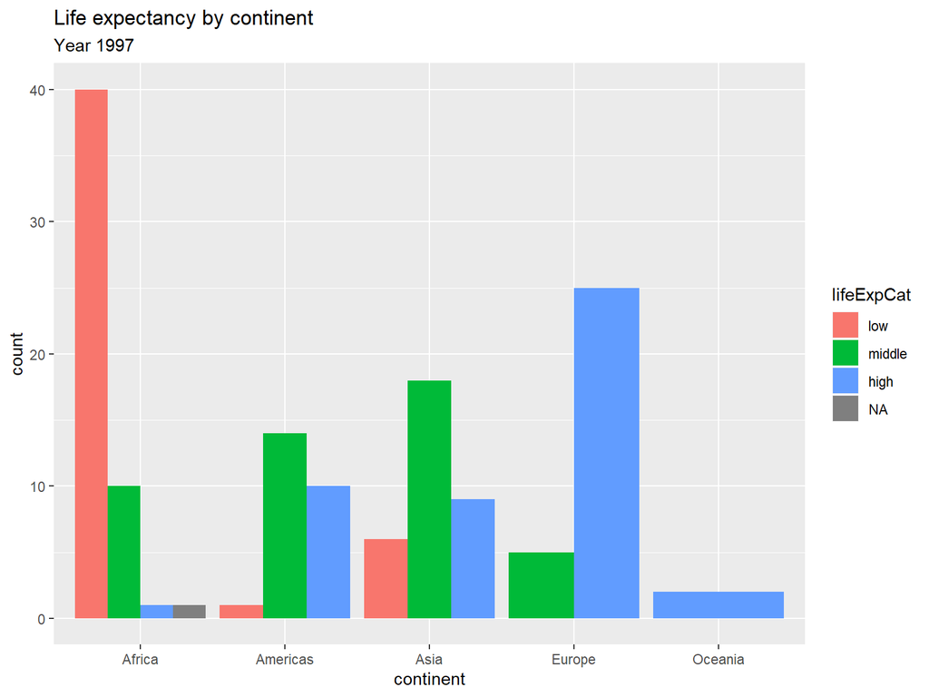

```r
ggplot(data = categorical_1997) +
  geom_bar(mapping = aes(x = continent,
                         fill = lifeExpCat),
           position = "dodge") +
  ggtitle(label = "Life expectancy by continent",
          subtitle = "Year 1997")
```

If we reverse the mapping of the variables `continent`and `lifeExpCat`, we can look at the data from a different angle.

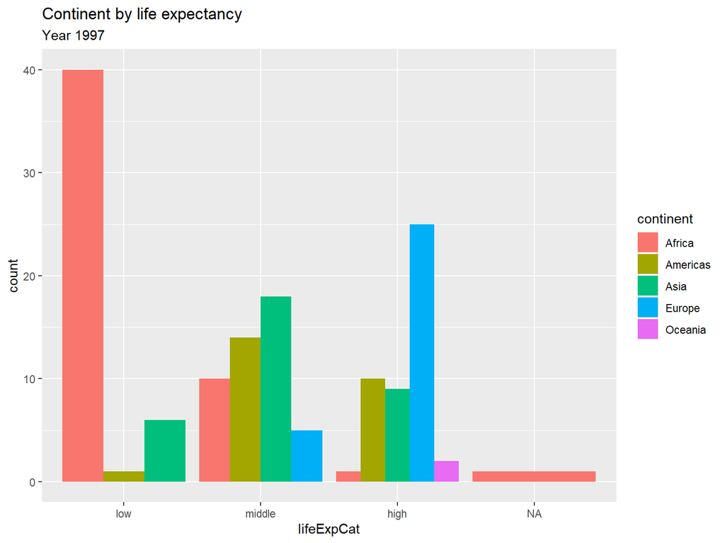

```r
ggplot(data = categorical_1997) +
  geom_bar(mapping = aes(x = lifeExpCat,
                         fill = continent),
           position = "dodge") +
  ggtitle(label = "Continent by life expectancy",
          subtitle = "Year 1997")
```

The corresponding contingency table is:

```r
table(categorical_1997$lifeExpCat,
      categorical_1997$continent)
```

```
##
##          Africa Americas Asia Europe Oceania
##   low        40        1    6      0       0
##   middle     10       14   18      5       0
##   high        1       10    9     25       2
```

## Count vs proportions

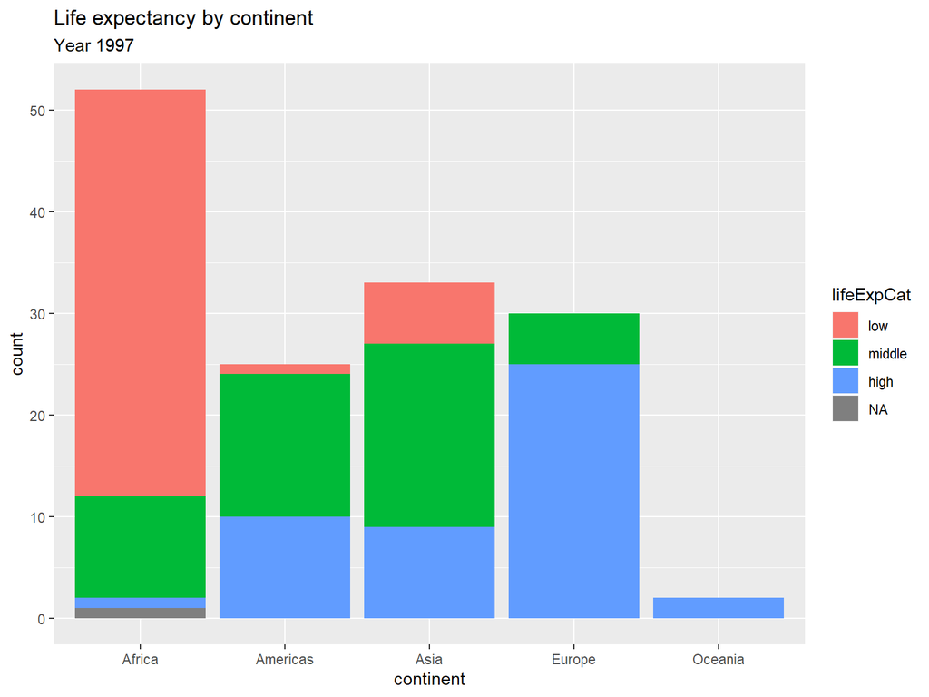

```r
ggplot(data = categorical_1997) +
  geom_bar(mapping = aes(x = continent,
                         fill = lifeExpCat)) +
  ggtitle(label = "Life expectancy by continent",
          subtitle = "Year 1997")
```

Use `position = "fill"`to change from count to proportion.

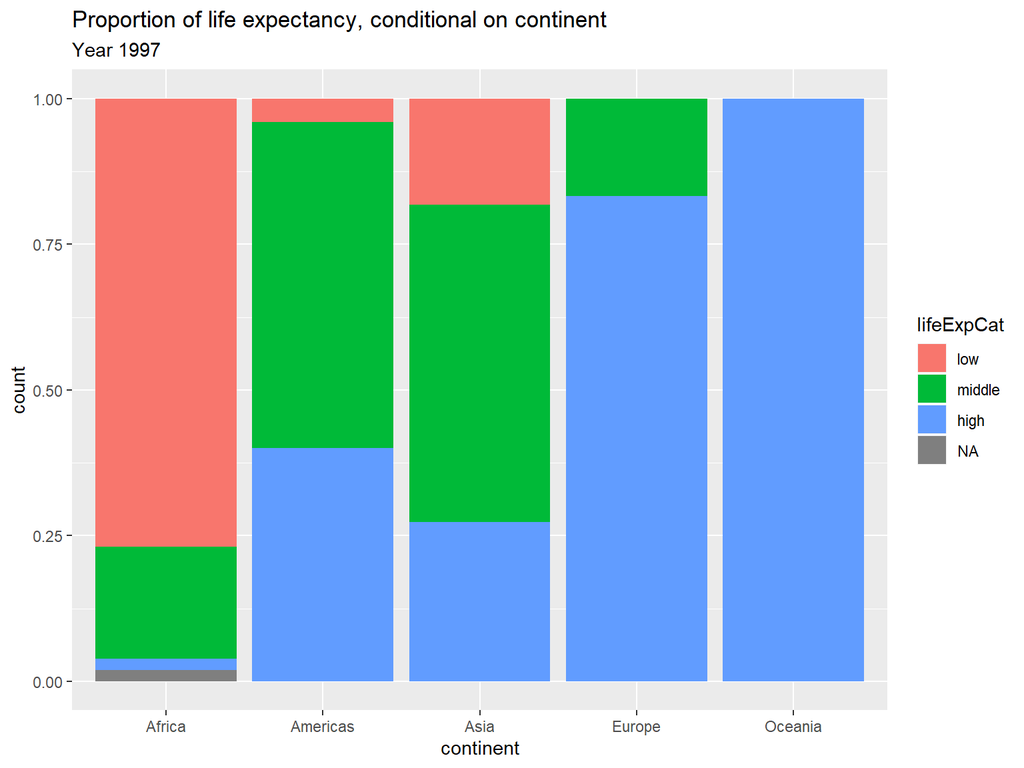

```r
ggplot(data = categorical_1997) +
  geom_bar(mapping = aes(x = continent,
                         fill = lifeExpCat),
           position = "fill") +
  ggtitle(label = "Proportion of life expectancy, conditional on continent",
          subtitle = "Year 1997")
```

# Exploring Numerical Data

## Faceted histogram

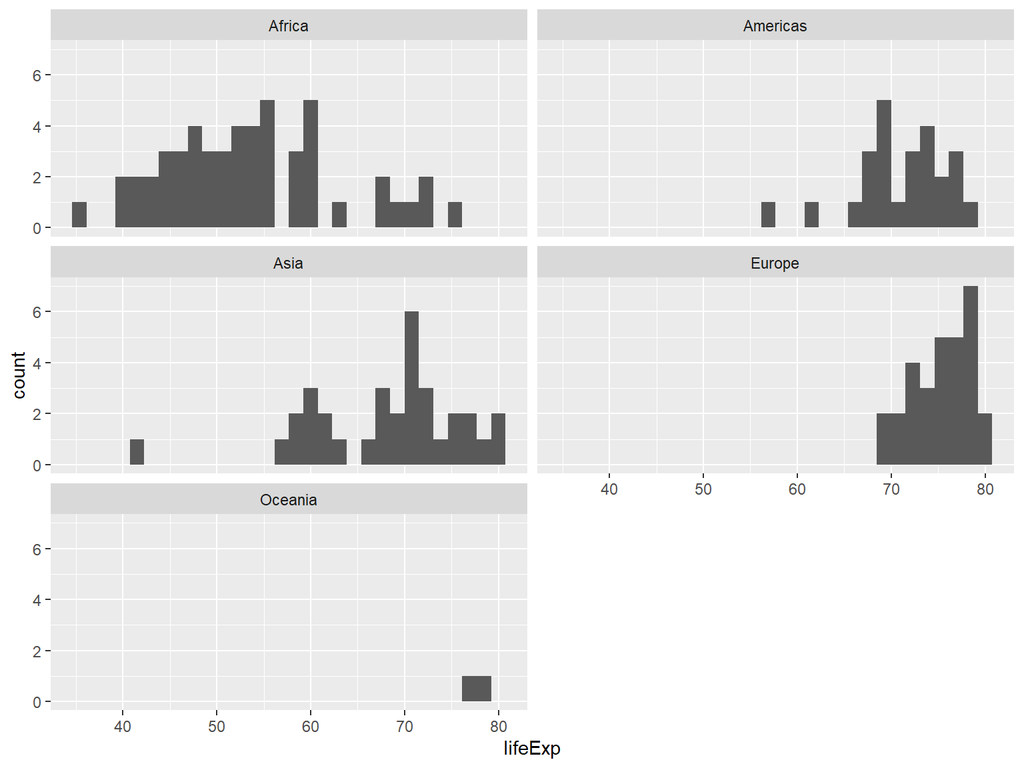

```r
ggplot(data = gapminder_1997) +
  geom_histogram(mapping = aes(x = lifeExp)) +
  facet_wrap(facets = ~ continent, nrow = 3)
```

## Boxplots

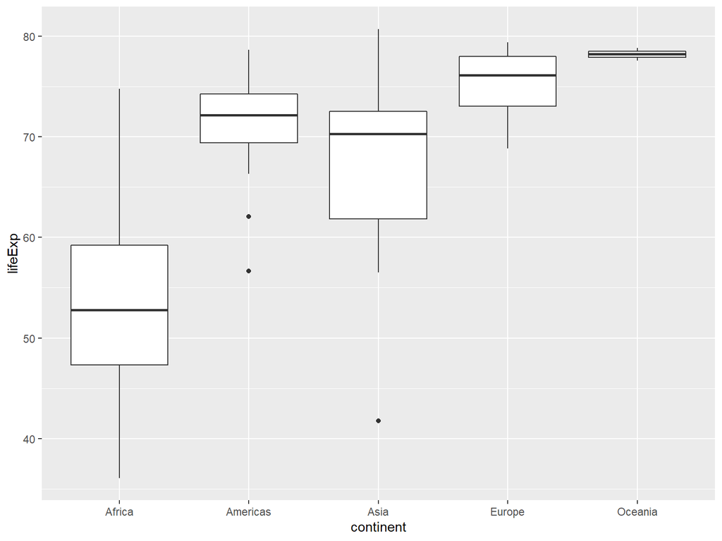

```r
ggplot(data = gapminder_1997) +
  geom_boxplot(mapping = aes(x = continent,
                             y = lifeExp))
```

## Density plots

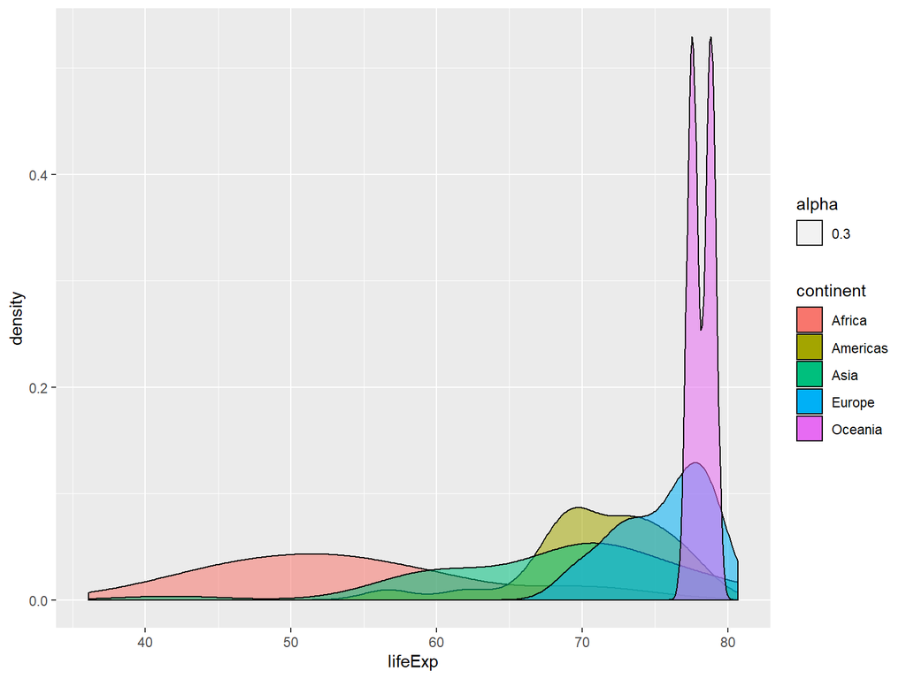

```r
ggplot(data = gapminder_1997) +
  geom_density(mapping = aes(x = lifeExp,
                             fill = continent,
                             alpha = .3))
```

## Marginal histogram

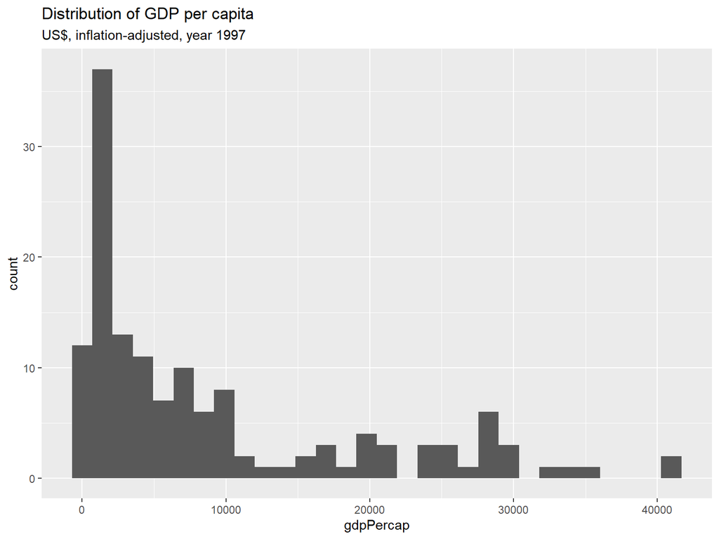

```r
ggplot(data = gapminder_1997) +
  geom_histogram(mapping = aes(x = gdpPercap)) +
  ggtitle(label = "Distribution of GDP per capita",
          subtitle = "US$, inflation-adjusted, year 1997")
```

## Conditional histogram

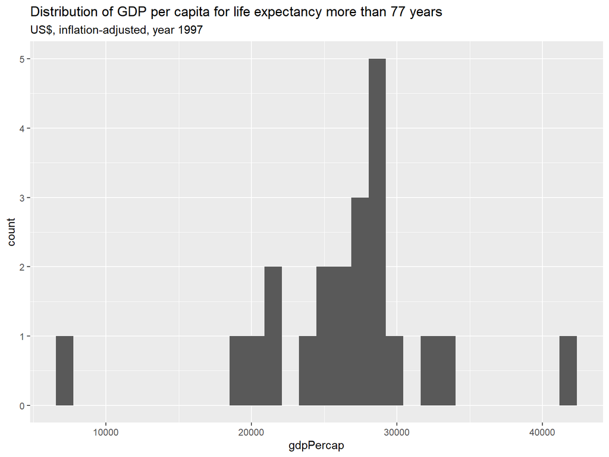

```r
ggplot(data = filter(gapminder_1997, lifeExp > 77)) +
  geom_histogram(mapping = aes(x = gdpPercap)) +
  ggtitle(label = "Distribution of GDP per capita for life expectancy more than 77 years",
          subtitle = "US$, inflation-adjusted, year 1997")
```

## Different binwidths

`?geom_histogram` contains the following information on binwidth and bins:

- `binwidth`  
  The width of the bins. Can be specified as a numeric value, or a function that calculates width from x. The default is to use bins bins that cover the range of the data. You should always override this value, exploring multiple widths to find the best to illustrate the stories in your data. The bin width of a date variable is the number of days in each time; the bin width of a time variable is the number of seconds.
- `bins`  
  Number of bins. Overridden by binwidth. Defaults to 30.

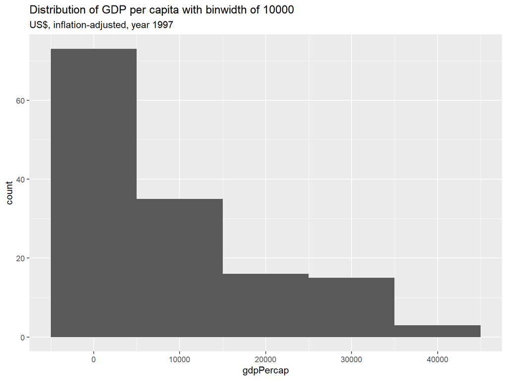

```r
ggplot(data = gapminder_1997) +
  geom_histogram(mapping = aes(x = gdpPercap),
                 binwidth = 10000) +
  ggtitle(label = "Distribution of GDP per capita with binwidth of 10000",
          subtitle = "US$, inflation-adjusted, year 1997")
```

What does a count of over 70 for the first bin mean?

```r
gapminder_1997 %>%
  filter(gdpPercap <= 5000) %>%
  summarize(count = n())
```

```
## # A tibble: 1 x 1
##   count
##   <int>
## 1    73
```

```r
gapminder_1997 %>%
  filter(gdpPercap > 5000 & gdpPercap <= 15000 ) %>%
  summarize(count = n())
```

```
## # A tibble: 1 x 1
##   count
##   <int>
## 1    35
```

How can we answer the above questions in a more principled manner?

```r
gapminder_1997 %>%
  mutate(bins = ifelse(gdpPercap > -5000 & gdpPercap <=  5000, 0,
                ifelse(gdpPercap >  5000 & gdpPercap <= 15000, 10000,
                ifelse(gdpPercap > 15000 & gdpPercap <= 25000, 20000,
                ifelse(gdpPercap > 25000 & gdpPercap <= 35000, 30000,
                                                               40000))))) %>%
  group_by(bins) %>%
  summarize(count = n())
```

```
## # A tibble: 5 x 2
##    bins count
##   <dbl> <int>
## 1     0    73
## 2 10000    35
## 3 20000    16
## 4 30000    15
## 5 40000     3
```

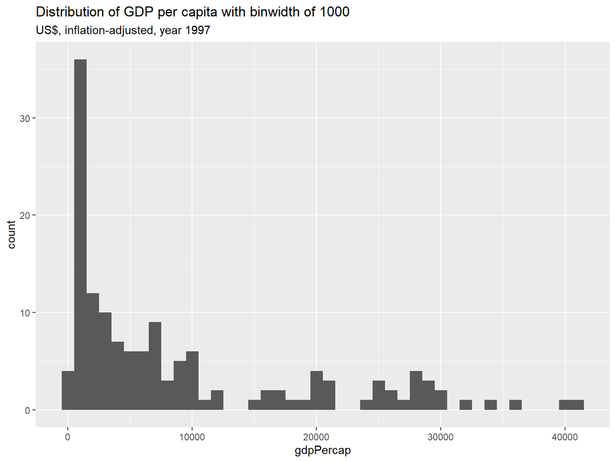

```r
ggplot(data = gapminder_1997) +
  geom_histogram(mapping = aes(x = gdpPercap),
                 binwidth = 1000) +
  ggtitle(label = "Distribution of GDP per capita with binwidth of 1000",
          subtitle = "US$, inflation-adjusted, year 1997")
```

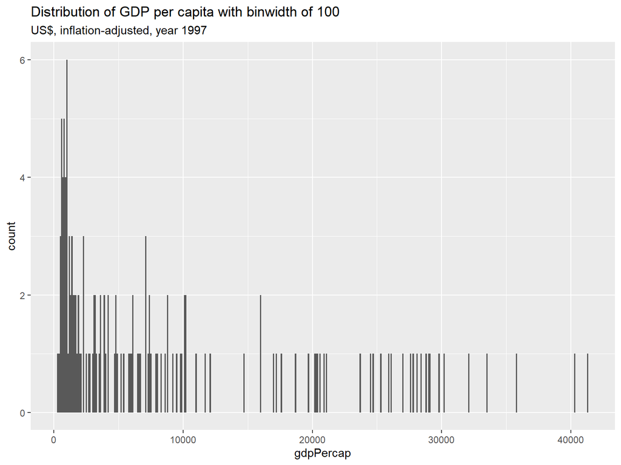

```r
ggplot(data = gapminder_1997) +
  geom_histogram(mapping = aes(x = gdpPercap),
                 binwidth = 100) +
  ggtitle(label = "Distribution of GDP per capita with binwidth of 100",
          subtitle = "US$, inflation-adjusted, year 1997")
```

## Box plots for outliers

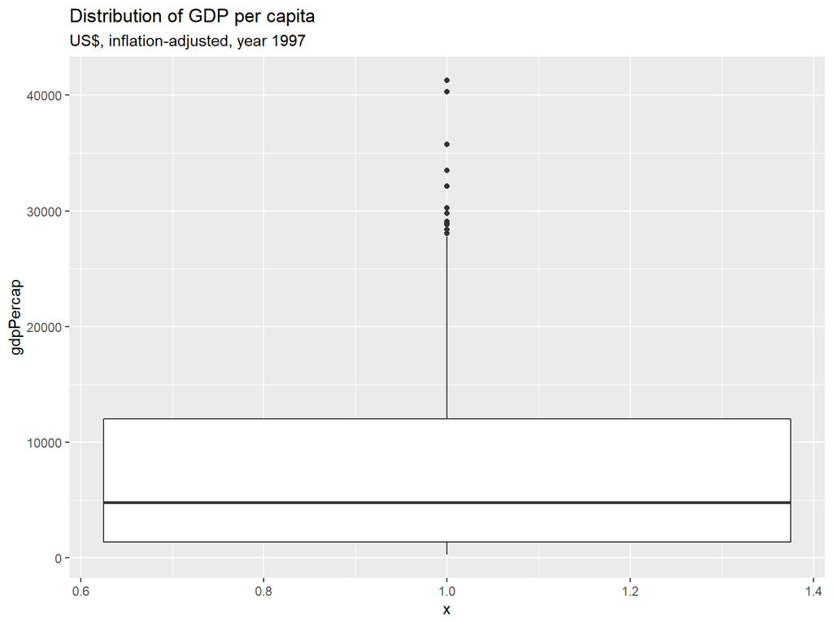

```r
  ggplot(data = gapminder_1997) +
  geom_boxplot(mapping = aes(x = 1,
                             y = gdpPercap)) +
  ggtitle(label = "Distribution of GDP per capita",
          subtitle = "US$, inflation-adjusted, year 1997")
```

Let us have a closer look at the five outliers with `gdpPercap > 32000`.

```r
gapminder_1997 %>%
  filter(gdpPercap > 32000)
```

```
## # A tibble: 5 x 6
##   country       continent  year lifeExp       pop gdpPercap
##   <fct>         <fct>     <int>   <dbl>     <int>     <dbl>
## 1 Kuwait        Asia       1997    76.2   1765345    40301.
## 2 Norway        Europe     1997    78.3   4405672    41283.
## 3 Singapore     Asia       1997    77.2   3802309    33519.
## 4 Switzerland   Europe     1997    79.4   7193761    32135.
## 5 United States Americas   1997    76.8 272911760    35767.
```

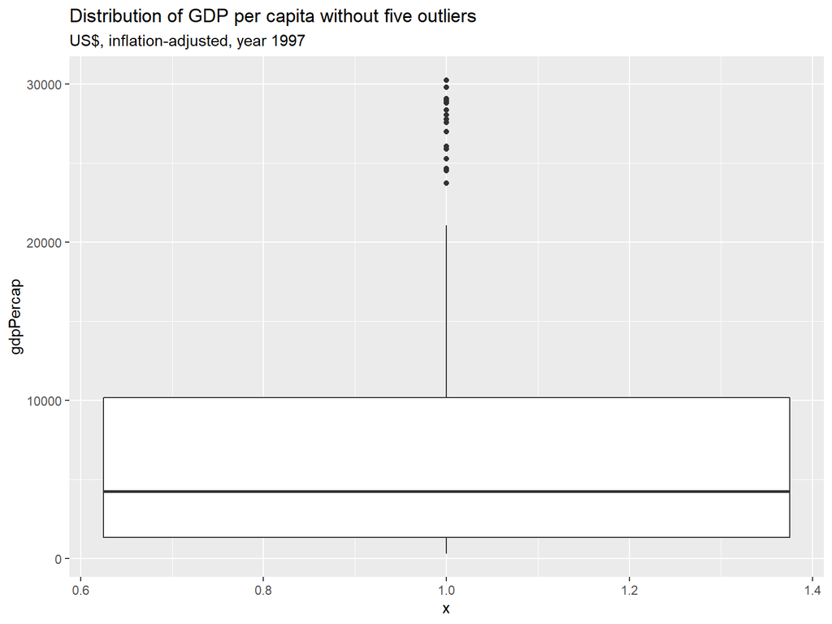

```r
  ggplot(data = filter(gapminder_1997, gdpPercap <= 32000)) +
  geom_boxplot(mapping = aes(x = 1,
                             y = gdpPercap)) +
  ggtitle(label = "Distribution of GDP per capita without five outliers",
          subtitle = "US$, inflation-adjusted, year 1997")
```

Let us have a closer look at the outliers with `gdpPercap <= 32000 & gdpPercap > 25000`.

```r
gapminder_1997 %>%
  filter(gdpPercap > 25000, gdpPercap <= 32000) %>%
  arrange(-gdpPercap)
```

```
## # A tibble: 13 x 6
##    country          continent  year lifeExp       pop gdpPercap
##    <fct>            <fct>     <int>   <dbl>     <int>     <dbl>
##  1 Netherlands      Europe     1997    78.0  15604464    30246.
##  2 Denmark          Europe     1997    76.1   5283663    29804.
##  3 Austria          Europe     1997    77.5   8069876    29096.
##  4 Canada           Americas   1997    78.6  30305843    28955.
##  5 Japan            Asia       1997    80.7 125956499    28817.
##  6 Hong Kong, China Asia       1997    80     6495918    28378.
##  7 Iceland          Europe     1997    79.0    271192    28061.
##  8 Germany          Europe     1997    77.3  82011073    27789.
##  9 Belgium          Europe     1997    77.5  10199787    27561.
## 10 Australia        Oceania    1997    78.8  18565243    26998.
## 11 United Kingdom   Europe     1997    77.2  58808266    26075.
## 12 France           Europe     1997    78.6  58623428    25890.
## 13 Sweden           Europe     1997    79.4   8897619    25267.
```

## Plot selection (check for bimodality and skewness)

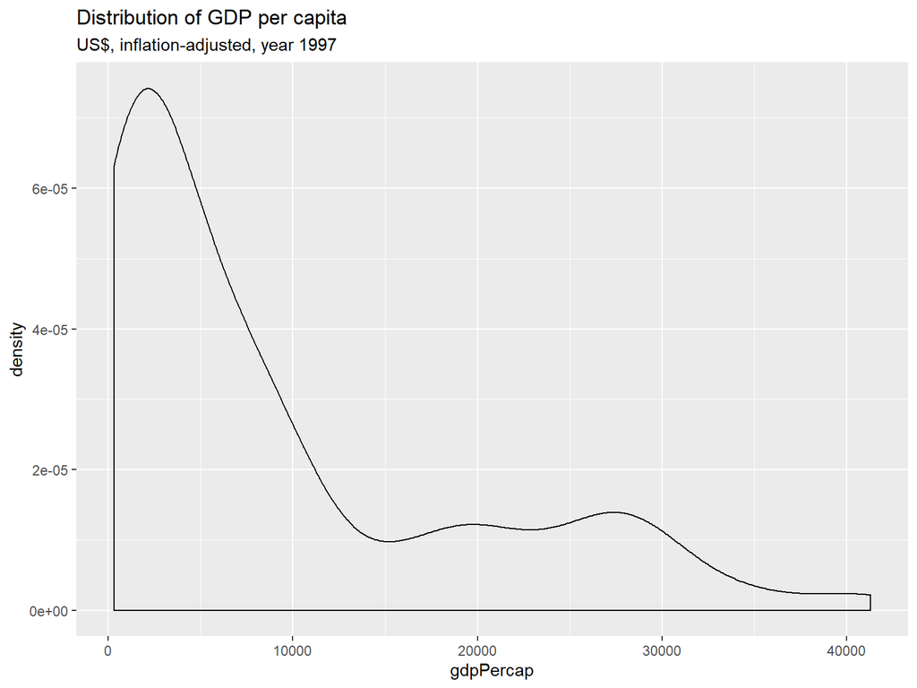

```r
  ggplot(data = gapminder_1997) +
  geom_density(mapping = aes(x = gdpPercap)) +
  ggtitle(label = "Distribution of GDP per capita",
          subtitle = "US$, inflation-adjusted, year 1997")
```

## Three variable plot

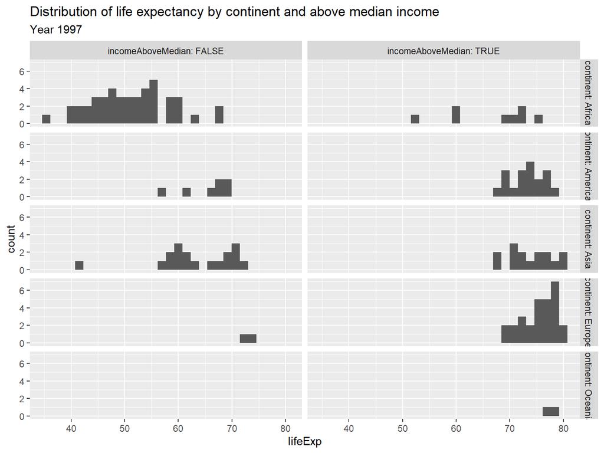

```r
gapminder_1997 <- gapminder_1997 %>%
  mutate(incomeAboveMedian = gdpPercap > median(gdpPercap))

ggplot(data = gapminder_1997) +
  geom_histogram(mapping = aes(x = lifeExp)) +
  facet_grid(continent ~ incomeAboveMedian,
             labeller = label_both) +
  ggtitle(label = "Distribution of life expectancy by continent and above median income",
          subtitle = "Year 1997")
```

Let us have a closer look at the African countries with above median income (at country level) and life expectancy below 65 (outliers).

```r
gapminder_1997 %>%
  filter(continent == "Africa",
         incomeAboveMedian,
         lifeExp <= 65)
```

```
## # A tibble: 3 x 7
##   country      continent  year lifeExp      pop gdpPercap incomeAboveMedian
##   <fct>        <fct>     <int>   <dbl>    <int>     <dbl> <lgl>
## 1 Botswana     Africa     1997    52.6  1536536     8647. TRUE
## 2 Gabon        Africa     1997    60.5  1126189    14723. TRUE
## 3 South Africa Africa     1997    60.2 42835005     7479. TRUE
```

# Numerical summaries

## Characeristics of a distribution

- center
- spread or variability
- shape which depends on modality and skew
- outliers

## Graphical tools for numerical data

Histogram

- aggregates continuous data into bins
- draws a bar with bar height representing the number of cases in that bin
- can be faceted by a categorical variable

Boxplot

- for comparing multiple distributions
- uses robust measures of center and spread: median and IQR (interquartile range)
- flags potential outliers
- do not use for multimodal distributions

Density plot

- draws a smooth line reprenting the shape of the distributon
- can be faceted or overlaid by mapping the categorical variable to `color` or `fill`

## Choice of center measure

Aim is to indentify a typical observation.

Mean: `mean()`

- commonly known and used
- but sensitive to extreme values

Median: `median()`

- middle value in a sorted data set
- use instead of mean if distribution is skewed

Important: Consider the shape of the distribution before selecting a measure of center.

## Calculate center measures

Compute groupwise mean and median `lifeExp` for each continent:

```r
gapminder_1997 %>%
  group_by(continent) %>%
  summarize(meanLifeExp = mean(lifeExp),
            medianLifeExp = median(lifeExp))
```

```
## # A tibble: 5 x 3
##   continent meanLifeExp medianLifeExp
##   <fct>           <dbl>         <dbl>
## 1 Africa           53.6          52.8
## 2 Americas         71.2          72.1
## 3 Asia             68.0          70.3
## 4 Europe           75.5          76.1
## 5 Oceania          78.2          78.2
```

Generate box plots of `lifeExp` for each continent to identify outliers:

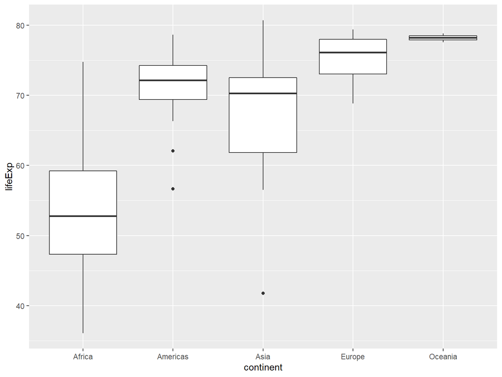

```r
  ggplot(data = gapminder_1997) +
    geom_boxplot(mapping = aes(x = continent,
                               y = lifeExp))
```

Use a density plot to inspect the shape of the distributions:

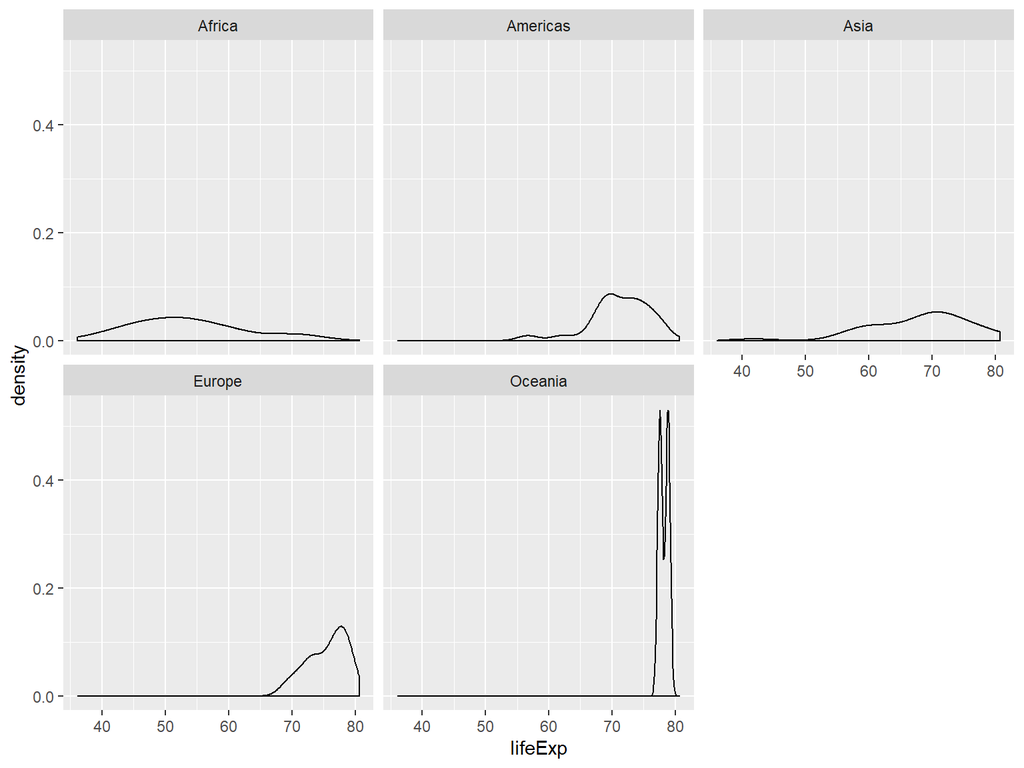

```r
ggplot(data = gapminder_1997) +
  geom_density(mapping = aes(x = lifeExp)) +
  facet_wrap(facets = ~ continent)
```

## Choice of spread measure

Aim is to indentify variability in our data.

Standard deviation: `sd()`

- commonly known and used
- easy interpretation because it is measured in the same unit as the raw data
- but sensitive to extreme values

IQR (interquartile range): `IQR()`

- distance between the first quartile and the third quartile
- @boxplot: equal to the height of the box
- use instead of standard deviation if distribution is skewed

Important: Consider the shape of the distribution before selecting a measure of spread.

## Calculate spread measures

Compute groupwise measures of spread and the count of countries for `lifeExp` by `continent`.

```r
gapminder_1997 %>%
  group_by(continent) %>%
  summarize(sd(lifeExp),
            IQR(lifeExp),
            n())
```

```
## # A tibble: 5 x 4
##   continent `sd(lifeExp)` `IQR(lifeExp)` `n()`
##   <fct>             <dbl>          <dbl> <int>
## 1 Africa            9.10           11.9     52
## 2 Americas          4.89            4.83    25
## 3 Asia              8.09           10.7     33
## 4 Europe            3.10            4.97    30
## 5 Oceania           0.905           0.64     2
```

Graphically compare the spread of the distributions with an overlaid density plots of `lifeExp` by `continent`.

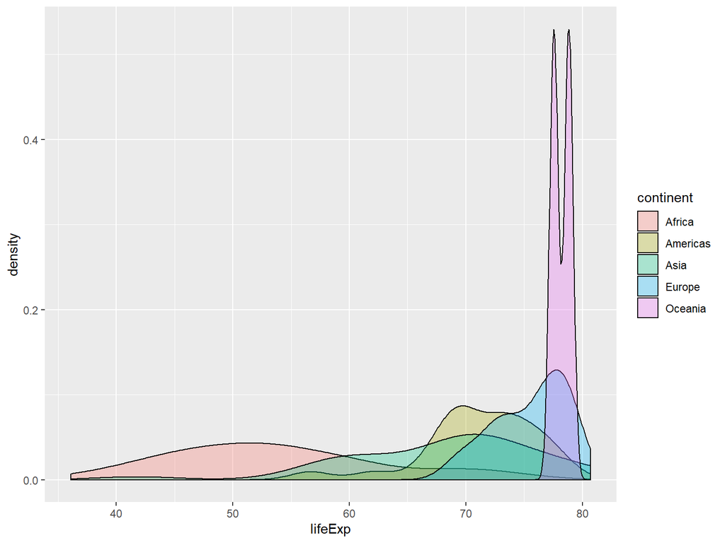

```r
  ggplot(gapminder_1997) +
  geom_density(aes(x = lifeExp,
                   fill = continent),
               alpha = 0.3)
```

Have a closer look at `Americas` and `Europe`.

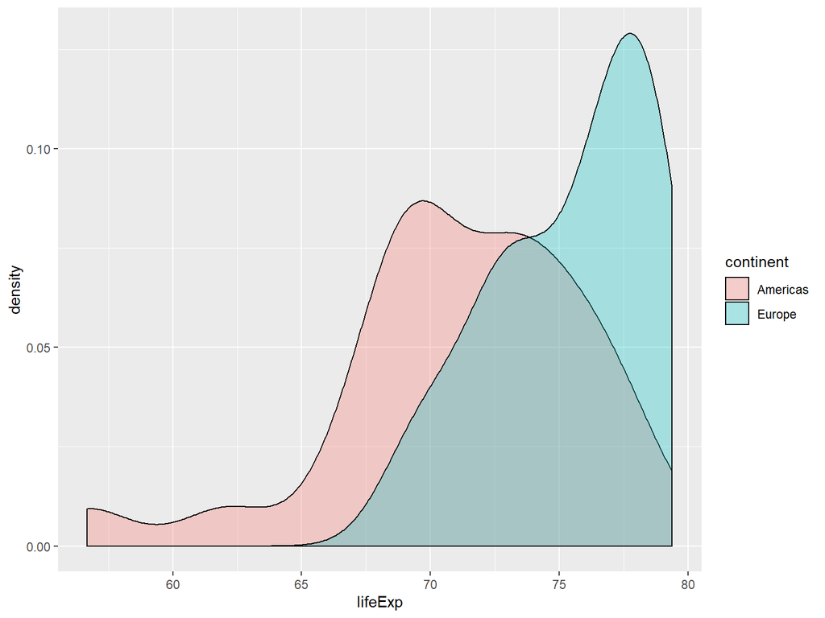

```r
AMEvsEUR <- gapminder_1997 %>%
  filter(continent %in% c("Americas", "Europe"))

ggplot(AMEvsEUR) +
  geom_density(aes(x = lifeExp,
                   fill = continent),
               alpha = 0.3)
```

## Choose measures for center and spread

The density plots show the shape of two distributions.

Select and calculate appropriate numerical summaries to describe their centers and spreads.

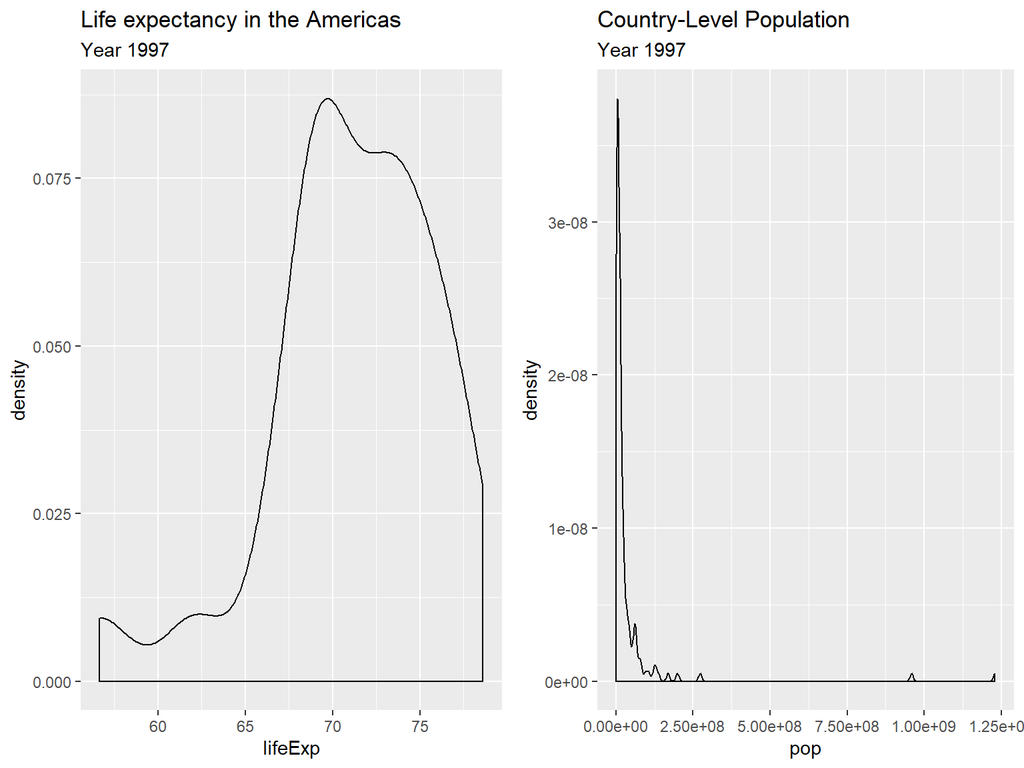

```r
p1 <- gapminder_1997 %>%
  filter(continent == "Americas") %>%
  ggplot() +
  geom_density(aes(x = lifeExp)) +
  ggtitle(label = "Life expectancy in the Americas",
          subtitle = "Year 1997")

p2 <- gapminder_1997 %>%
  ggplot() +
  geom_density(aes(x = pop)) +
  ggtitle(label = "Country-Level Population",
          subtitle = "Year 1997")

grid.arrange(p1, p2, ncol = 2)
```

Compute stats for `lifeExp` in Americas

```r
gapminder_1997 %>%
  filter(continent == "Americas") %>%
  summarize(mean(lifeExp),
            sd(lifeExp),
            median(lifeExp),
            IQR(lifeExp))
```

```
## # A tibble: 1 x 4
##   `mean(lifeExp)` `sd(lifeExp)` `median(lifeExp)` `IQR(lifeExp)`
##             <dbl>         <dbl>             <dbl>          <dbl>
## 1            71.2          4.89              72.1           4.83
```

Compute statistics for `pop`

```r
gapminder_1997 %>%
  summarize(mean(pop),
            sd(pop),
            median(pop),
            IQR(pop))
```

```
## # A tibble: 1 x 4
##   `mean(pop)`  `sd(pop)` `median(pop)` `IQR(pop)`
##         <dbl>      <dbl>         <dbl>      <dbl>
## 1   38839468. 133417391.      9735064.   20541220
```

Remember: Like mean and standard deviation, median and IQR measure the central tendency and spread, respectively, but are robust to outliers and non-normal data.

## Transformations

Highly skewed distributions can make it very difficult to learn anything from a visualization. Transformations can be helpful in revealing the more subtle structure.

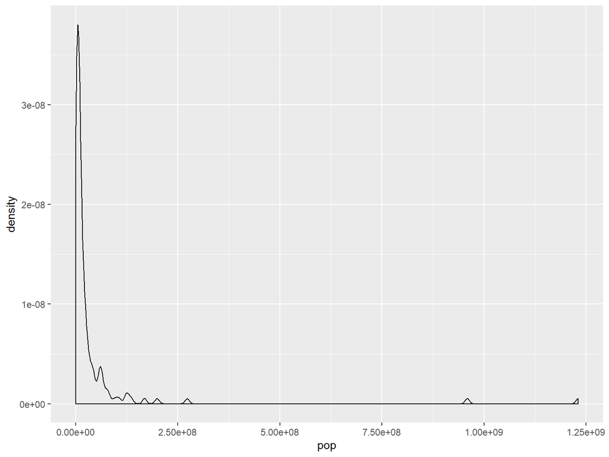

```r
# Create density plot of old variable
gapminder_1997 %>%
  ggplot(aes(x = pop)) +
  geom_density()
```

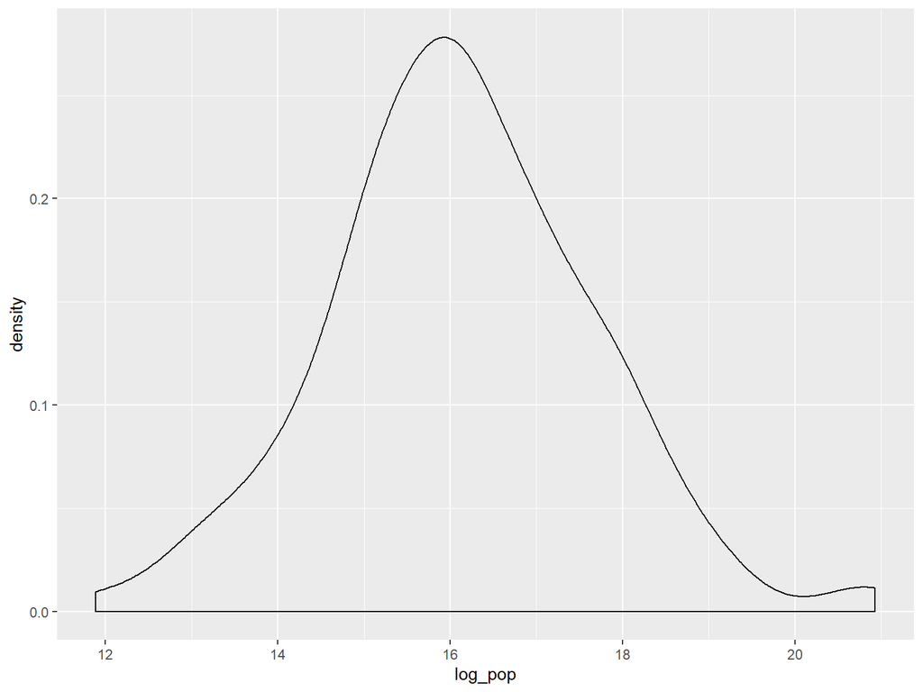

```r
# Transform the skewed pop variable
gapminder_1997 <- gapminder_1997 %>%
  mutate(log_pop = log(pop))

# Create density plot of new variable
gapminder_1997 %>%
  ggplot(aes(x = log_pop)) +
  geom_density()
```

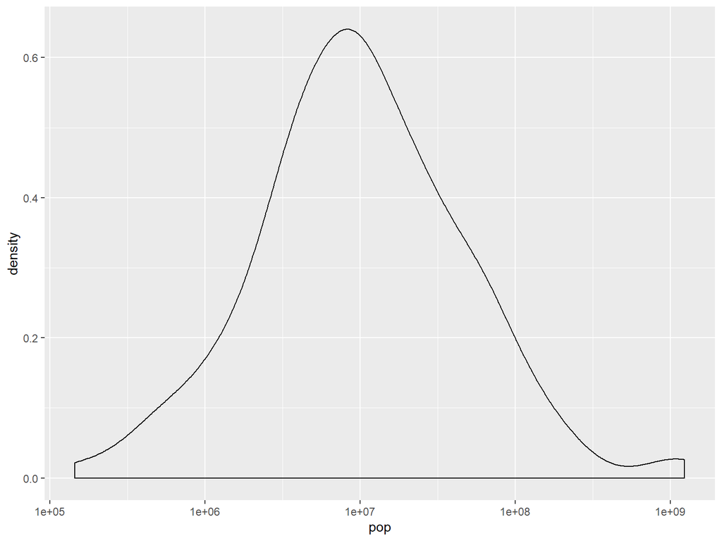

```r
# Alternative way: Scaling
gapminder_1997 %>%
  ggplot(aes(x = pop)) +
  geom_density() +
  scale_x_log10()
```

## Identify outliers

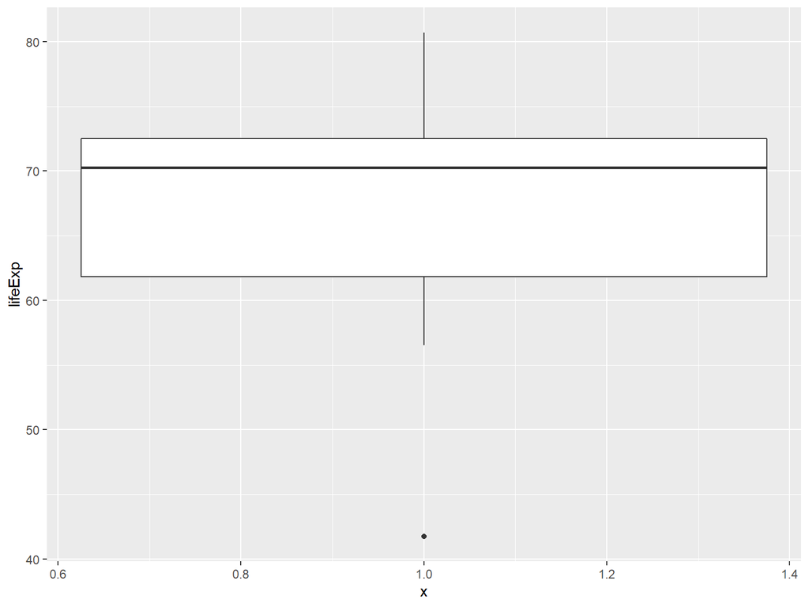

```r
# Filter for Asia, create box plot of lifeExp
gapminder_1997 %>%
  filter(continent == "Asia") %>%
  ggplot(aes(x = 1, y = lifeExp)) +
  geom_boxplot()
```

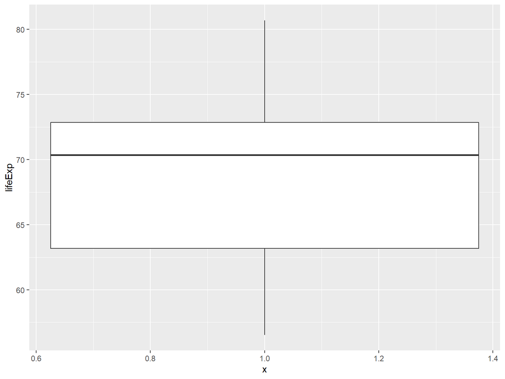

```r
# Filter for Asia, add column indicating outliers
gap_asia <- gapminder_1997 %>%
  filter(continent == "Asia") %>%
  mutate(is_outlier = lifeExp < 50)

# Remove outliers, create box plot of lifeExp
gap_asia %>%
  filter(is_outlier == FALSE) %>%
  ggplot(aes(x = 1, y = lifeExp)) +
  geom_boxplot()
```